# Marine Aquaculture

Melissa Widas

2022-11-16

## Overview

Marine aquaculture has the potential to play an important role in the global food supply as a more sustainable protein option than land-based meat production.[^1] [Gentry et al.](https://www.nature.com/articles/s41559-017-0257-9) mapped the potential for marine aquaculture globally based on multiple constraints, including ship traffic, dissolved oxygen, bottom depth .[^2]

In the following analysis we will be determining which Exclusive Economic Zones (EEZ) on the West Coast of the US are best suited to developing marine aquaculture for several species of oysters.

Based on previous research, we know that oysters needs the following conditions for optimal growth:

- sea surface temperature: 11-30°C
- depth: 0-70 meters below sea level

##### Highlights:

- combining vector/raster data
- resampling raster data
- masking raster data
- map algebra

### Data

#### Sea Surface Temperature

We will use average annual sea surface temperature (SST) from the years 2008 to 2012 to characterize the average sea surface temperature within the region. The data we are working with was originally generated from [NOAA’s 5km Daily Global Satellite Sea Surface Temperature Anomaly v3.1](https://coralreefwatch.noaa.gov/product/5km/index_5km_ssta.php).

#### Bathymetry

To characterize the depth of the ocean we will use the [General Bathymetric Chart of the Oceans (GEBCO)](https://www.gebco.net/data_and_products/gridded_bathymetry_data/#area).[^3]

#### Exclusive Economic Zones

We will be designating maritime boundaries using Exclusive Economic Zones off of the west coast of US from [Marineregions.org](https://www.marineregions.org/eez.php).

#### Geographic Context

We will use a shapefile that has the outline of the United States and its State components from the [United States Census Bureau](https://www.census.gov/geographies/mapping-files/time-series/geo/cartographic-boundary.html) at the national scale.

## Exploration

Data was loaded in including sea surface temperatures, depth, and Exclusive Economic Zone boundaries off of the west coast of the United States.

```r
# load packages
library(here)
library(tidyverse)
library(sf)
library(terra)
library(ggspatial)
library(patchwork)

# read in the shapefile for the West Coast EEZ (`wc_regions_clean.shp`)
wc <- read_sf(here("data","wc_regions_clean.shp"))

# read in SST rasters
sst_2008 <- rast(here("data", "average_annual_sst_2008.tif"))
sst_2009 <- rast(here("data", "average_annual_sst_2009.tif"))
sst_2010 <- rast(here("data", "average_annual_sst_2010.tif"))
sst_2011 <- rast(here("data", "average_annual_sst_2011.tif"))
sst_2012 <- rast(here("data", "average_annual_sst_2012.tif"))

# read in depth raster
depth <- rast(here("data", "depth.tif"))
```

Next, we will process the SST and depth data so that they can be combined. In order to combine these data we will be resampling the depth data so that we do not change the underlying data.

```r
# stack annual data
sst <- c(sst_2008, sst_2009, sst_2010, sst_2011, sst_2012)


# reproject Coordinate System
st_crs(sst)     # WGS84, EPSG 9122
```

```
## Coordinate Reference System:
##   User input: WGS 84
##   wkt:
## GEOGCRS["WGS 84",
##     DATUM["unknown",
##         ELLIPSOID["WGS84",6378137,298.257223563,
##             LENGTHUNIT["metre",1,
##                 ID["EPSG",9001]]]],
##     PRIMEM["Greenwich",0,
##         ANGLEUNIT["degree",0.0174532925199433,
##             ID["EPSG",9122]]],
##     CS[ellipsoidal,2],
##         AXIS["latitude",north,
##             ORDER[1],
##             ANGLEUNIT["degree",0.0174532925199433,
##                 ID["EPSG",9122]]],
##         AXIS["longitude",east,
##             ORDER[2],
##             ANGLEUNIT["degree",0.0174532925199433,
##                 ID["EPSG",9122]]]]
```

```r
st_crs(wc)       # WGS84 EPSG 4326
```

```
## Coordinate Reference System:
##   User input: WGS 84
##   wkt:
## GEOGCRS["WGS 84",
##     DATUM["World Geodetic System 1984",
##         ELLIPSOID["WGS 84",6378137,298.257223563,
##             LENGTHUNIT["metre",1]]],
##     PRIMEM["Greenwich",0,
##         ANGLEUNIT["degree",0.0174532925199433]],
##     CS[ellipsoidal,2],
##         AXIS["latitude",north,
##             ORDER[1],
##             ANGLEUNIT["degree",0.0174532925199433]],
##         AXIS["longitude",east,
##             ORDER[2],
##             ANGLEUNIT["degree",0.0174532925199433]],
##     ID["EPSG",4326]]
```

```r
st_crs(depth)         # WGS84, EPSG 4326
```

```
## Coordinate Reference System:
##   User input: WGS 84
##   wkt:
## GEOGCRS["WGS 84",
##     ENSEMBLE["World Geodetic System 1984 ensemble",
##         MEMBER["World Geodetic System 1984 (Transit)"],
##         MEMBER["World Geodetic System 1984 (G730)"],
##         MEMBER["World Geodetic System 1984 (G873)"],
##         MEMBER["World Geodetic System 1984 (G1150)"],
##         MEMBER["World Geodetic System 1984 (G1674)"],
##         MEMBER["World Geodetic System 1984 (G1762)"],
##         MEMBER["World Geodetic System 1984 (G2139)"],
##         ELLIPSOID["WGS 84",6378137,298.257223563,
##             LENGTHUNIT["metre",1]],
##         ENSEMBLEACCURACY[2.0]],
##     PRIMEM["Greenwich",0,
##         ANGLEUNIT["degree",0.0174532925199433]],
##     CS[ellipsoidal,2],
##         AXIS["geodetic latitude (Lat)",north,
##             ORDER[1],
##             ANGLEUNIT["degree",0.0174532925199433]],
##         AXIS["geodetic longitude (Lon)",east,
##             ORDER[2],
##             ANGLEUNIT["degree",0.0174532925199433]],
##     USAGE[
##         SCOPE["Horizontal component of 3D system."],
##         AREA["World."],
##         BBOX[-90,-180,90,180]],
##     ID["EPSG",4326]]
```

```r
sst <- project(sst, depth)
```

```
##
|---------|---------|---------|---------|
=========================================
```

```r
st_crs(sst)     # WGS84, EPSG 4326
```

```
## Coordinate Reference System:
##   User input: WGS 84
##   wkt:
## GEOGCRS["WGS 84",
##     ENSEMBLE["World Geodetic System 1984 ensemble",
##         MEMBER["World Geodetic System 1984 (Transit)"],
##         MEMBER["World Geodetic System 1984 (G730)"],
##         MEMBER["World Geodetic System 1984 (G873)"],
##         MEMBER["World Geodetic System 1984 (G1150)"],
##         MEMBER["World Geodetic System 1984 (G1674)"],
##         MEMBER["World Geodetic System 1984 (G1762)"],
##         MEMBER["World Geodetic System 1984 (G2139)"],
##         ELLIPSOID["WGS 84",6378137,298.257223563,
##             LENGTHUNIT["metre",1]],
##         ENSEMBLEACCURACY[2.0]],
##     PRIMEM["Greenwich",0,
##         ANGLEUNIT["degree",0.0174532925199433]],
##     CS[ellipsoidal,2],
##         AXIS["geodetic latitude (Lat)",north,
##             ORDER[1],
##             ANGLEUNIT["degree",0.0174532925199433]],
##         AXIS["geodetic longitude (Lon)",east,
##             ORDER[2],
##             ANGLEUNIT["degree",0.0174532925199433]],
##     USAGE[
##         SCOPE["Horizontal component of 3D system."],
##         AREA["World."],
##         BBOX[-90,-180,90,180]],
##     ID["EPSG",4326]]
```

```r
# Find mean Sea Surface Temperature

# Collapse down layers to one SST mean and convert to celcius
sst_mean <- mean(sst)
```

```
##
|---------|---------|---------|---------|
=========================================
```

```r
sst_mean <- (sst_mean$mean - 273.15)

# Check they will match
sst_depth <- c(depth, sst_mean)

depth_crop <- crop(depth, sst_mean)

depth_crop_res <- resample(x= depth_crop, y = sst_mean, method = "near")
```

```
##
|---------|---------|---------|---------|
=========================================
```

```r
# stack annual data
sst_depth <- c(sst_mean, depth_crop_res)
sst_depth_rast <- rast(sst_depth)
```

In order to find suitable locations for marine aquaculture, and in this case oysters, we’ll need to find locations that are suitable in terms of both SST and depth. We will use reclassification matrices in order to achieve this. We will then create an overlay using the `lapp()` function multiplying cell values to determine which cells are suitable oyster environment.

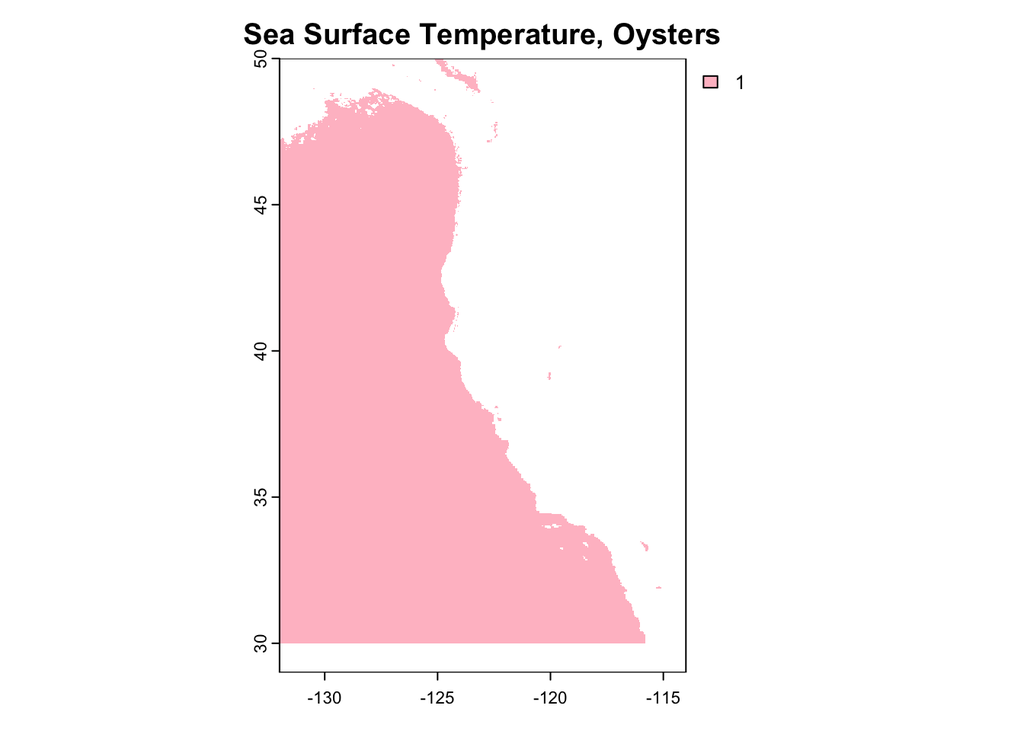

```r
# Reclassification for sst
sst_reclass <- matrix(c(-Inf, 11, NA,
                   11, 30, 1,        # sea surface temperature: 11-30°C
                   30, Inf, NA),
                     ncol = 3, byrow = TRUE)
oyster_sst <- classify(sst_mean, rcl = sst_reclass)
plot(oyster_sst, col = "pink",
     main = "Sea Surface Temperature, Oysters")
```

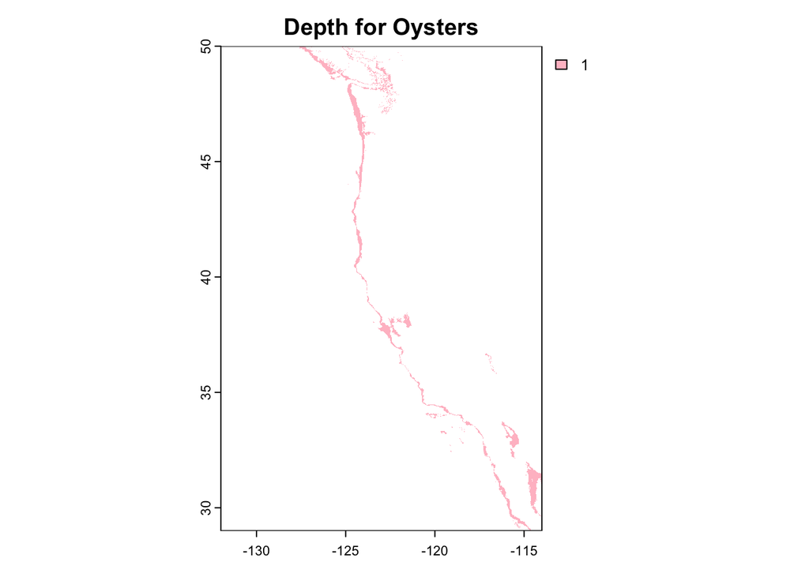

```r
# Reclassification for depth
depth_reclass <- matrix(c(-Inf, -70, NA,
                     -70, 0, 1,      # depth: 0-70 meters below sea level
                     0, Inf, NA),
                     ncol = 3, byrow = TRUE)
oyster_depth <- classify(depth_crop_res, rcl = depth_reclass)
plot(oyster_depth, col = "pink",
     main = "Depth for Oysters")
```

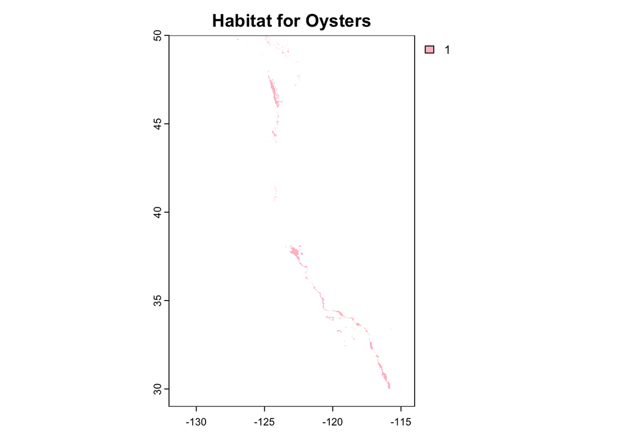

```r
# Overlay to find areas that satisfy BOTH
fun_mult = function(x,y){return(x*y)}     # function to multiply layers

oyster_both <- lapp(c(oyster_sst, oyster_depth), fun_mult)
plot(oyster_both, col = "pink",
     main = "Habitat for Oysters")
```

To determine the total suitable area within each EEZ in order to rank zones by priority we will find the total area of suitable locations within each EEZ. We will then perform a percentage calculation in order to determine the percentage of suitable area per EEZ.

```r
# Turn Regions data into raster
wc$rgn <- as.factor(wc$rgn)
wc_raster <- rasterize(vect(wc), oyster_both, field = "rgn") # use vect to create a spatial vector


# Select suitable cells in EEZ
suitable_mask <- mask(wc_raster, oyster_both)


# Find total suitable area within each EEZ
oyster_area <- expanse(suitable_mask, unit = "km", byValue = TRUE) # use expanse to calculate the area


# Find percentage of each zone
oyster_region <- cbind(oyster_area, wc)
oyster_region <- oyster_region %>%
  mutate(percent = (area / area_km2)*100)
```

We will now create the following maps showcasing the total suitable area by region and the percent suitable area by region.

```r
# load data for USA
usa <- read_sf(here("data", "cb_2022_us_state_500k", "cb_2022_us_state_500k.shp"))

# filter data to just west coast which is our area of interest
west_coast <- usa %>%
  filter(NAME %in% c("Washington", "Oregon", "California"))
```

```
## Scale on map varies by more than 10%, scale bar may be inaccurate
```

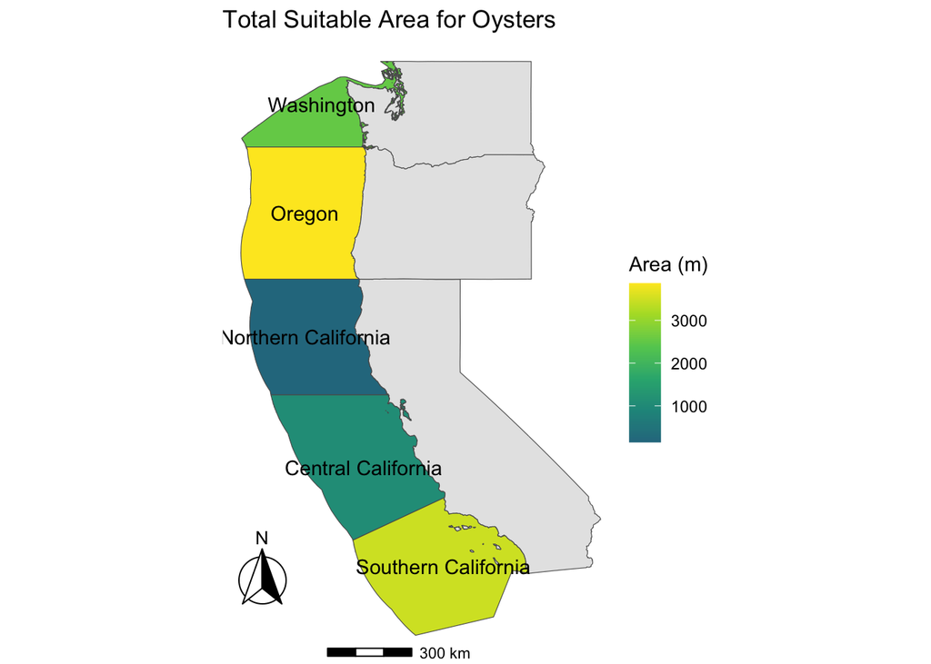

```r
# create visualization for total suitable area by region
total_area_region <- ggplot() +
  geom_sf(data = oyster_region, # plot the oyster regions
          aes(fill = area, geometry = geometry)) +# fill by area
  geom_sf(data = west_coast) +
  geom_sf_text(data = oyster_region, aes(geometry = geometry, label = rgn)) +
 labs(fill='Area (m)') + # alter legend title
  scale_fill_viridis_c(begin = 0.4) +
  theme_void() +
  annotation_north_arrow( # add north arrow
  height = unit(1.5, "cm"),
  width = unit(1.5, "cm"),
  pad_x = unit(0, "cm"),
  pad_y = unit(1, "cm"),
  rotation = NULL,
  style = north_arrow_fancy_orienteering
) +
  annotation_scale( # add scale bar
  plot_unit = NULL,
  bar_cols = c("black", "white"),
  line_width = 1,
  height = unit(0.15, "cm"),
  pad_x = unit(2, "cm"),
  pad_y = unit(0.15, "cm"),
  text_pad = unit(0.15, "cm"),
  text_cex = 0.7,
  text_face = NULL,
  text_family = "",
  tick_height = 0.6
) +
  labs(title= "Total Suitable Area for Oysters", color = "") # add map title

total_area_region
```

```
## Scale on map varies by more than 10%, scale bar may be inaccurate
```

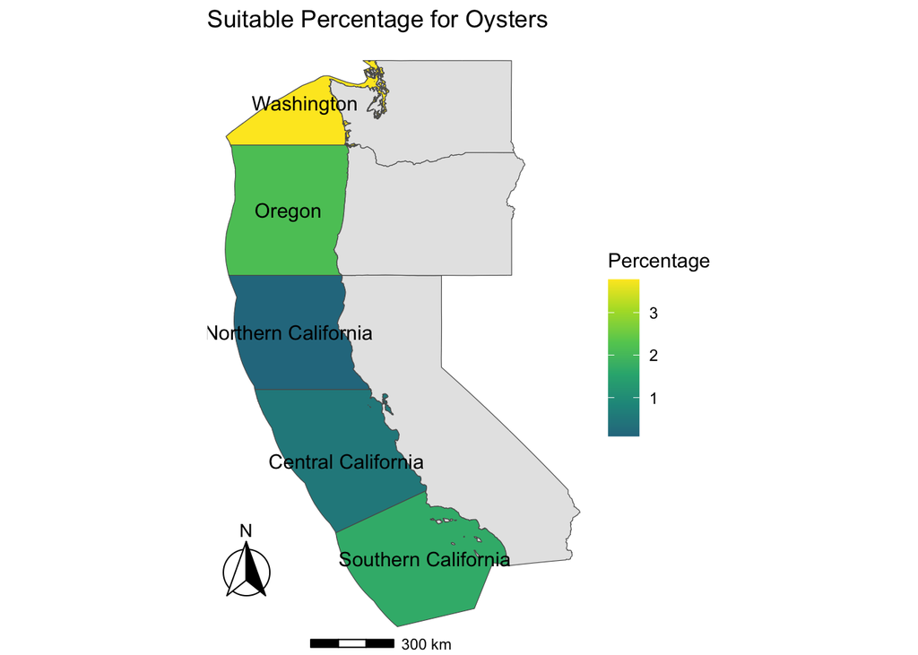

```r
# create visualization for percent suitable area by region
percent_region <- ggplot() +
  geom_sf(data = oyster_region, # plot the oyster regions
          aes(fill = percent, geometry = geometry)) + # fill by percent
  geom_sf(data = west_coast) +
  geom_sf_text(data = oyster_region, aes(geometry = geometry, label = rgn)) +
  scale_fill_viridis_c(begin = 0.4) +
 labs(fill='Percentage') +
  theme_void() +
  annotation_north_arrow( # add north arrow
  height = unit(1.5, "cm"),
  width = unit(1.5, "cm"),
  pad_x = unit(0, "cm"),
  pad_y = unit(1, "cm"),
  rotation = NULL,
  style = north_arrow_fancy_orienteering
) +
  annotation_scale( # add scale bar
  plot_unit = NULL,
  bar_cols = c("black", "white"),
  line_width = 1,
  height = unit(0.15, "cm"),
  pad_x = unit(2, "cm"),
  pad_y = unit(0.15, "cm"),
  text_pad = unit(0.15, "cm"),
  text_cex = 0.7,
  text_face = NULL,
  text_family = "",
  tick_height = 0.6
) +
  labs(title= "Suitable Percentage for Oysters", color = "") # add map title

percent_region
```

```
## Scale on map varies by more than 10%, scale bar may be inaccurate
## Scale on map varies by more than 10%, scale bar may be inaccurate
```

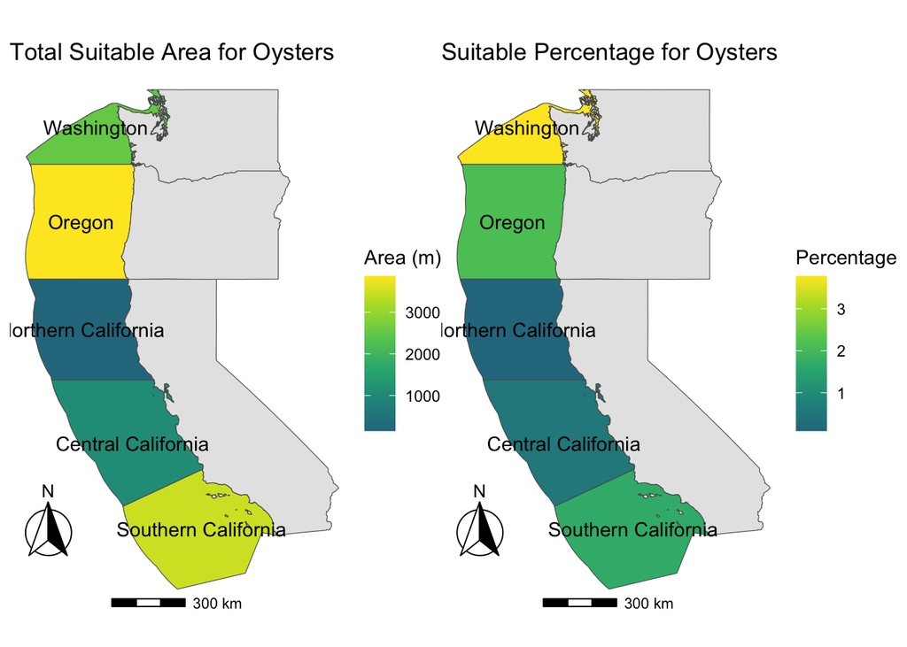

```r
# combne area and region plots into same viewer
total_area_region+percent_region
```

#### Broaden your workflow! (40 points)

Now that we’ve created a workflow for oysters, we will update our workflow to work for other species. To achieve this we will create a function that accepts temperature and depth ranges and species name as inputs and ultimately produces maps of the total suitable area and percents.

The function we will create named aquaculture_regions will then be demonstrated on Pandalus jordani, or more commonly known as pink shrimp. Pink Shrimp are found at these conditions from [NOAA](https://www.fisheries.noaa.gov/species/pink-shrimp):

- sea surface temperature: 6-12°C
- depth: 36-437 meters below sea level

```r
aquaculture_regions <- function(species_name, min_temp, max_temp, max_depth, min_depth){

  # reclassify
  sst_reclass <- matrix(c(-Inf, min_temp, NA,
                          min_temp, max_temp, 1,
                          max_temp, Inf, NA),
                        ncol = 3, byrow = TRUE)
  depth_reclass <- matrix(c(-Inf, max_depth, NA,
                            max_depth, min_depth, 1,
                            min_depth, Inf, NA),
                          ncol = 3, byrow = TRUE)

  # apply reclassify
  species_sst <- classify(sst_mean, rcl = sst_reclass)
  species_depth <- classify(depth, rcl = depth_reclass)
  fun_mult = function(x,y){return(x*y)}     # function to multiply layers
  species_suitable <- lapp(c(species_sst, species_depth), fun_mult)

  # Turn Regions data into raster
  wc$rgn <- as.factor(wc$rgn)
  wc_raster <- rasterize(vect(wc), species_suitable, field = "rgn")


  # Select suitable cells in EEZ
  species_mask <- mask(wc_raster, species_suitable)


  # Find total suitable area within each EEZ
  species_area <- expanse(species_mask, unit = "km", byValue = TRUE)


  # Find percentage of each zone
  species_region <- cbind(species_area, wc)
  species_region <- species_region %>%
    mutate(percent = (area / area_km2)*100)

  # create visualization for total suitable area by region
  total_area_region <- ggplot() +
    geom_sf(data = species_region, # plot the oyster regions
            aes(fill = area, geometry = geometry)) + # fill by area
    geom_sf(data = west_coast) +
    geom_sf_text(data = species_region, aes(geometry = geometry, label = rgn)) +
    scale_fill_viridis_c(begin = 0.4) +
    labs(fill='Area (m)') + # alter legend title
    theme_void() +
    annotation_north_arrow( # add north arrow
      height = unit(1.5, "cm"),
      width = unit(1.5, "cm"),
      pad_x = unit(0, "cm"),
      pad_y = unit(1, "cm"),
      rotation = NULL,
      style = north_arrow_fancy_orienteering
    ) +
    annotation_scale( # add scale bar
      plot_unit = NULL,
      bar_cols = c("black", "white"),
      line_width = 1,
      height = unit(0.15, "cm"),
      pad_x = unit(2, "cm"),
      pad_y = unit(0.15, "cm"),
      text_pad = unit(0.15, "cm"),
      text_cex = 0.7,
      text_face = NULL,
      text_family = "",
      tick_height = 0.6
    ) +
    labs(title = print(paste0("Total Suitable Area for ", species_name))) # add map title

  total_area_region

  # create visualization for total suitable area by region
  percent_region <- ggplot() +
    geom_sf(data = species_region, # plot the oyster regions
            aes(fill = percent, geometry = geometry)) + # fill by percentage
    geom_sf(data = west_coast) +
    geom_sf_text(data = species_region, aes(geometry = geometry, label = rgn)) +
    scale_fill_viridis_c(begin = 0.4) +
    labs(fill='Percentage') + # alter legend title
    theme_void() +
    annotation_north_arrow( # add north arrow
      height = unit(1.5, "cm"),
      width = unit(1.5, "cm"),
      pad_x = unit(1, "cm"),
      pad_y = unit(1, "cm"),
      rotation = NULL,
      style = north_arrow_fancy_orienteering
    ) +
    annotation_scale( # add scale bar
      plot_unit = NULL,
      bar_cols = c("black", "white"),
      line_width = 1,
      height = unit(0.15, "cm"),
      pad_x = unit(2, "cm"),
      pad_y = unit(0.15, "cm"),
      text_pad = unit(0.15, "cm"),
      text_cex = 0.7,
      text_face = NULL,
      text_family = "",
      tick_height = 0.6
    ) +
    labs(title = print(paste0("Suitable Percentage for ", species_name))) # add map title

  percent_region

  total_area_region+percent_region
}
```

```r
# test aquaculture_regions function on pink shrimp
aquaculture_regions(species_name = "Shrimp", min_temp = 6, max_tem = 12, max_depth = -437, min_depth = -36 )
```

```
## [1] "Total Suitable Area for Shrimp"
## [1] "Suitable Percentage for Shrimp"
```

```
## Scale on map varies by more than 10%, scale bar may be inaccurate
## Scale on map varies by more than 10%, scale bar may be inaccurate
```

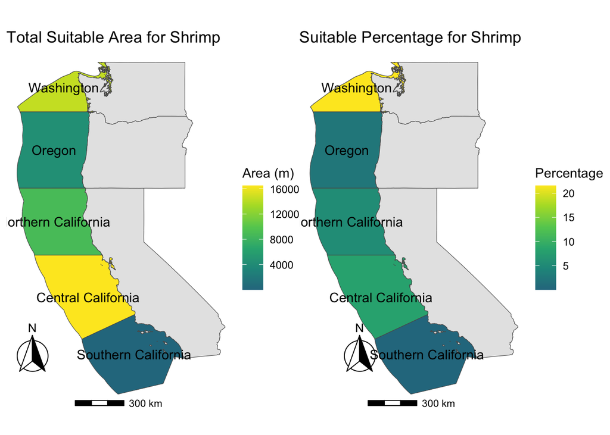

[^1]: Hall, S. J., Delaporte, A., Phillips, M. J., Beveridge, M. & O’Keefe, M. Blue Frontiers: Managing the Environmental Costs of Aquaculture (The WorldFish Center, Penang, Malaysia, 2011).
[^2]: Gentry, R. R., Froehlich, H. E., Grimm, D., Kareiva, P., Parke, M., Rust, M., Gaines, S. D., & Halpern, B. S. Mapping the global potential for marine aquaculture. *Nature Ecology & Evolution*, 1, 1317-1324 (2017).
[^3]: GEBCO Compilation Group (2022) GEBCO_2022 Grid (doi:10.5285/e0f0bb80-ab44-2739-e053-6c86abc0289c).